# Homework: Manipulating Data

Firstname Lastname

## Instructions

When you are finished with the assignment:

1. Save the file as 06_Lastname_Firstname.Rmd and compile it
2. Commit the Rmd file and corresponding html file to your homework git repo
3. Push the commit to github
4. Locate the Rmd file on github and click on the SHA link for the file
5. Paste the url of the resulting page into Canvas to submit your assignment.

Your assignment must compile on a different computer as long as the saspath is set correctly for that machine. This means you will need to use a local file path when you read the data in via R (and SAS).

## Poetry? The `R`aven

(In case it isn’t obvious, do this part in R)

We can of course read in data from any number of sources, but we can also use R to analyze poetry and written text. Poetry is particularly interesting as it typically is stored in lines and stanzas, making it an ideal structured text to read in and create variables for. In this exercise, you’ll be playing around with a poem and using string functions to explore the poem. We haven’t covered string functions formally yet, so this is also a chance to explore the `stringr` package on your own (we’ll formally talk about strings more next week). Think of this as good practice for reading the documentation of a package and learning how to leverage that documentation to accomplish a task.

> “The Raven” is a narrative poem by American writer Edgar Allan Poe. First published in January 1845, the poem is often noted for its musicality, stylized language, and supernatural atmosphere. Sitting on a bust of Pallas, the raven seems to further distress the protagonist with its constant repetition of the word “Nevermore”. The poem makes use of folk, mythological, religious, and classical references. – [Wikipedia](https://en.wikipedia.org/wiki/The_Raven)

Read in the lines of text in “The Raven” and write code to do the following tasks:

1. Create a tibble with a column that contains the lines of the poem (leave the blank lines in for now)
2. Count the number of words in each line. Do you see any patterns?
3. Can you use this information to create a variable with stanza numbers?
4. Create a column with line numbers (within each stanza)
5. Split the lines of the poem into words (you can discard punctuation). Is there any discernible pattern?

```r
library(dplyr)
library(tidyr)
library(stringr)
library(quanteda)
```

```r
library(nsyllable)
library(ggplot2)

raven <- readLines('the_raven_poe.txt')

raven_tb <- tibble(lines = raven) %>%
            mutate(n_word = str_count(lines, '[A-z][[:punct:][:space:]]')) %>%
            mutate(stanza = cumsum(n_word == 0)+ 1) %>%
            mutate(overall_line = 1:n()) %>%
            filter(n_word > 0) %>%
            group_by(stanza) %>%
            mutate(stanza_line = 1:n())

raven_wd <- raven_tb %>%
            mutate(word = str_split(lines, '[[:space:][:punct:]]', simplify = F)) %>%
            unnest(c(word)) %>%
            filter(nchar(str_trim(word))>0) %>%
            group_by(overall_line) %>%
            mutate(n_line_word = 1:n())
```

If you are interested, you can use the `nsyllable` function in the R package `quanteda` to get syllable counts and continue the exploration.

```r
raven_syllable <- raven_wd %>%
                  mutate(n_word_syllable = nsyllable(word)) %>%
                  group_by(stanza_line) %>%
                  mutate(n_line_syllable = cumsum(n_word_syllable))
```

#### Plot data

*1. line vs number of words per line*  
*2. line with in one stanza vs number of words per line*

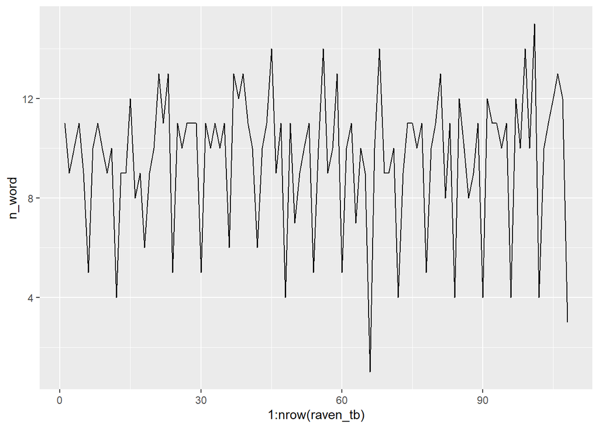

```r
ggplot(raven_tb, aes(x = 1:nrow(raven_tb), y = n_word))+geom_line()
```

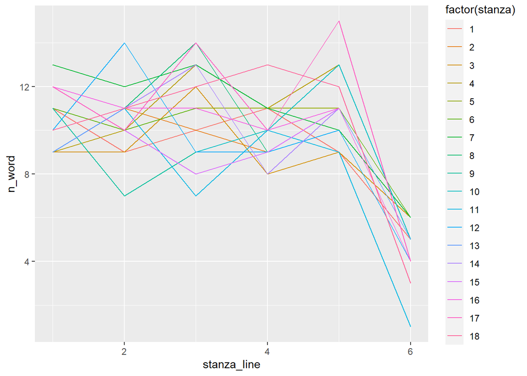

```r
ggplot(raven_tb, aes(x=stanza_line, y=n_word, color = factor(stanza))) + geom_line()
```

*The number of each line generally follows a long-short pattern with few fluctuations in one pattern.*

##### syllables of words with in a line vs number of syllables in each line

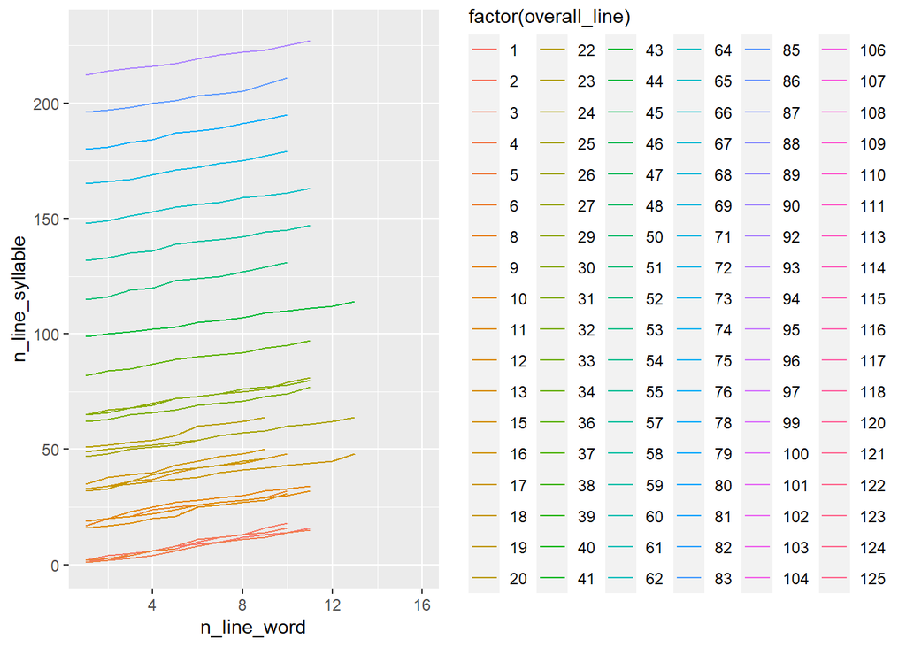

```r
ggplot(raven_syllable, aes(x=n_line_word, y=n_line_syllable, color=factor(overall_line)))+geom_line()
```

*In each line of the poem, the number of syllables increases within a line. Generally speaking, if we look at the trend of the whole poem, it starts with a less syllable line, then lines with more reaches the maximum at 90th-100th line, and eventually back to lines with less number of syllables.*

##### Use of the word ‘chamber’ in Edgar Allan Poe’s the raven

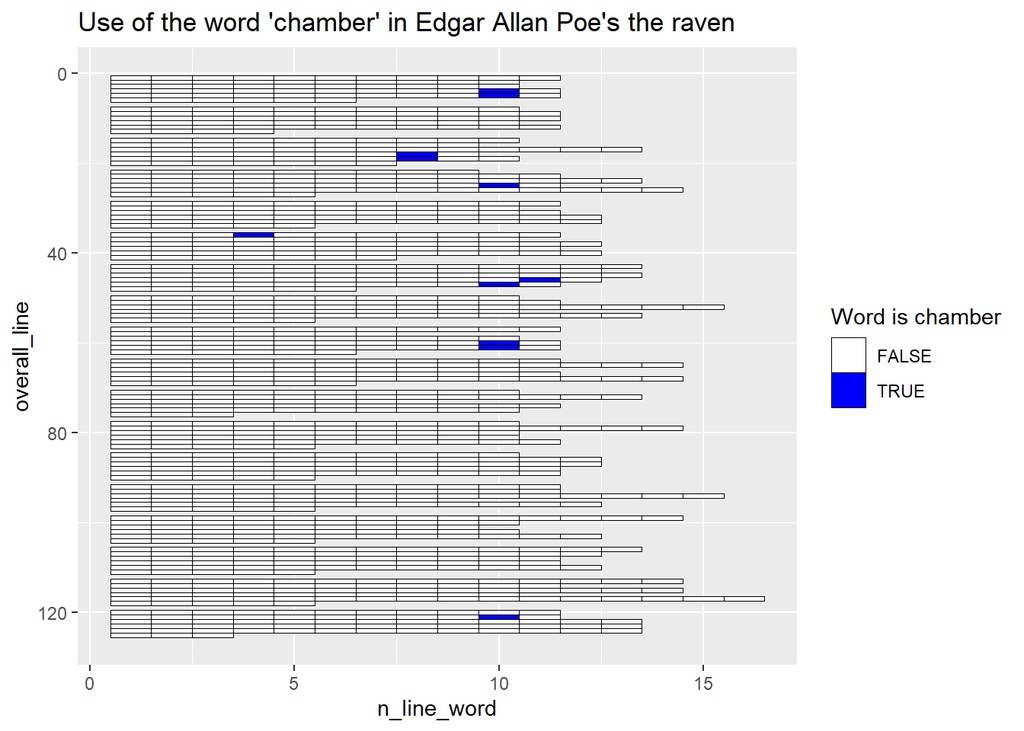

```r
ggplot(raven_wd, aes(x = n_line_word, y = overall_line,
                       fill = str_detect(word, "chamber"))) +
  geom_tile(color = "black") +
  scale_fill_manual("Word is chamber", values = c("FALSE" = "white", "TRUE" = "blue")) +
  # Make the tiles start at the top for line 1, like we would read in a poem
  scale_y_reverse() +
  ggtitle("Use of the word 'chamber' in Edgar Allan Poe's the raven")
```

Hints: `stringr` is the package for text manipulation. `str_split` will split lines into words. You may also find `unnest` from the `tidyr` package to be useful

You can get a preview of next week’s material that covers `stringr` in more detail [here](https://srvanderplas.github.io/unl-stat850/transforming-data.html#string-operations-creating-new-variables-and-separating-multi-variable-columns)